# Heritability: from family data and from summary statistics

**Purpose.** Heritability is the fraction of the variation in a trait that is explained by genetics. This notebook estimates it twice, by two very different routes, and the comparison is the point of the exercise.

1. **GCTA on genotypes.** With a genetic relationship matrix built from the SNPs themselves, a mixed model splits the phenotypic variance into a genetic and a residual part. This needs individual-level data.
2. **LD score regression on summary statistics.** With nothing but a published GWAS, the relationship between a SNP's LD score and its test statistic separates **real polygenic signal** from **confounding** such as population structure or cryptic relatedness. This is why an inflated QQ plot is not by itself evidence of a problem — LD score regression tells you which of the two you are looking at.

Along the way you will also run an association test that accounts for relatedness, and see what the inflation factor does and does not tell you.

**The data — two datasets, one per half.**

- **Part 1, family data.** A simulated human cohort of **related individuals** with a quantitative phenotype, as **called genotypes** in PLINK binary format (`quantfamdata.bed/.bim/.fam`). The relatedness is what makes it a family dataset and what makes a naive association test fail.
- **Part 2, summary statistics.** Published GWAS summary statistics from **Biobank Japan** for two cholesterol measurements, **HDL** and **LDL** (`BBJ_HDLC`, `BBJ_LDLC`) — an **East Asian** cohort, which is why the LD reference panel used below is the East Asian one (`eas_ldscores`). No genotypes are involved in this half.

## Setup

All the paths used by this exercise are set in the cell below.

```
#############################################################
# ALL PATHS ARE SET HERE
# If the data or the software moves, this is the ONLY cell you
# need to change. No cell below this one uses a full path.
#############################################################
DATA=/course/data/current_data/heritability_ldscore
SCRIPTS=/course/data/current_data/scripts
GENETIC_MAP=/course/data/current_data/geneticMap/hg19

# LD score regression. NOTE: the conda environment this was written for is not
# on this server. The commands are left in place and the *munged* files they
# produce are supplied with the data, so the rest of the exercise still works.
LDSC_DIR=/home/jonas/anders_neededConda/ldsc
LDSC_ENV="conda run -n ldsc"
LDSC_MUNGE="${LDSC_ENV} ${LDSC_DIR}/munge_sumstats.py"
LDSC="${LDSC_ENV} ${LDSC_DIR}/ldsc.py"

WORK_DIR=$HOME/heritability_ldscore_human
mkdir -p $WORK_DIR
cd $WORK_DIR

# R and Python cannot read bash variables, so write the paths to a file they can read
cat > $WORK_DIR/env.sh <<EOF
export DATA=$DATA
export SCRIPTS=$SCRIPTS
export WORK=$WORK_DIR
EOF

ls -l $DATA/
```

```
# R cannot source env.sh, so read the paths out of it rather than repeating them
env <- readLines(path.expand("~/heritability_ldscore_human/env.sh"))
getvar <- function(k) sub(paste0('^export ', k, '='), '', grep(paste0('^export ', k, '='), env, value = TRUE)[1])
DATA <- getvar("DATA"); SCRIPTS <- getvar("SCRIPTS"); WORK <- getvar("WORK")
setwd(WORK)
source(file.path(SCRIPTS, "online.R"))
```

```
# Python reads the same file
import os
env = dict(l.strip().removeprefix("export ").split("=", 1)
           for l in open(os.path.expanduser("~/heritability_ldscore_human/env.sh")) if "=" in l)
DATA, SCRIPTS, WORK = env["DATA"], env["SCRIPTS"], env["WORK"]
os.chdir(WORK)
```

# Part 1: heritability from family data

Unpack the genotypes.

```
source ~/heritability_ldscore_human/env.sh
cd $WORK

cp -f $DATA/quantfam.zip .
unzip -o quantfam.zip

echo ----- files in folder -----
ls
```

```
Archive:  quantfam.zip
  inflating: multipleGRMs6andnot6.txt
  inflating: multipleGRMsnot6.txt
  inflating: multipleGRMs.txt
  inflating: myphenos.txt
  inflating: quantfamdata.fam
  inflating: quantfamdata.bim
  inflating: quantfamdata.bed
  inflating: manifest.csv
----- files in folder -----
BBJ_HDLC.sumstats.gz  GCTAgrm.log		myphenos.txt
BBJ_HDLC.txt.gz       GCTAherit.hsq		quantfamdata.bed
BBJ_LDLC.sumstats.gz  GCTAherit.log		quantfamdata.bim
BBJ_LDLC.txt.gz       GCTAresults.log		quantfamdata.fam
eas_ldscores	      GCTAresults.mlma		quantfam.zip
env.sh		      manifest.csv		unrelated.family.txt
GCTAgrm.grm.bin       multipleGRMs6andnot6.txt	unrelated.log
GCTAgrm.grm.id	      multipleGRMsnot6.txt	unrelated.singleton.txt
GCTAgrm.grm.N.bin     multipleGRMs.txt		w_hm3.snplist
```

You should now have three PLINK binary files in your directory: `quantfamdata.bed`, `quantfamdata.bim` and `quantfamdata.fam`.

The phenotype is in the sixth column of the `.fam` file. GCTA wants it in a separate file, so extract it.

```
fam <- read.table("./quantfamdata.fam", header = FALSE)
pheno <- data.frame(fam[,1:2], fam[,6])
write.table(pheno, file = "./myphenos.txt", quote = FALSE, row.names = FALSE, col.names = FALSE)

cat("individuals:", nrow(fam), "\n")
hist(pheno[,3], main = "the quantitative phenotype", xlab = "phenotype")
```

```
individuals: 498
```

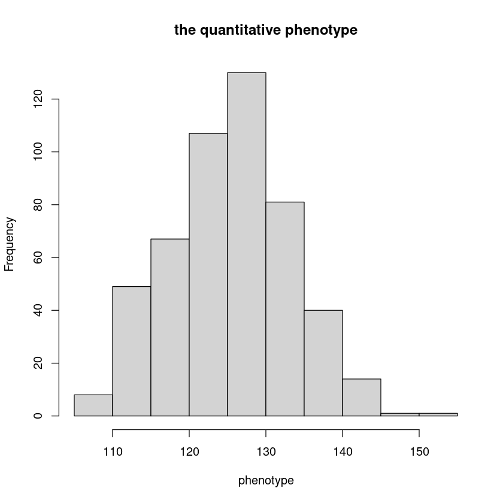

- How many individuals are there?
- Does the phenotype look normally distributed? A mixed model assumes the residuals are.

## Step 2: association testing that accounts for relatedness

GCTA's `--mlma` fits a mixed linear model, so the relatedness between individuals is modelled rather than ignored.

```
source ~/heritability_ldscore_human/env.sh
cd $WORK

# 1.5 min to run
gcta64 --mlma --bfile quantfamdata --pheno myphenos.txt --out GCTAresults
```

```
* Genome-wide Complex Trait Analysis (GCTA)
* version v1.94.4 Linux
* Built at Apr  7 2025 11:00:19, by GCC 8.3
* (C) 2010-present, Yang Lab, Westlake University
* Please report bugs to Jian Yang <jian.yang@westlake.edu.cn>
Analysis started at 08:49:06 CEST on Thu Sep 17 2026.
Hostname: emily

Accepted options:
--mlma
--bfile quantfamdata
--pheno myphenos.txt
--out GCTAresults

Note: This is a multi-thread program. You could specify the number of threads by the --thread-num option to speed up the computation if there are multiple processors in your machine.

Reading PLINK FAM file from [quantfamdata.fam].
498 individuals to be included from [quantfamdata.fam].
Reading PLINK BIM file from [quantfamdata.bim].
134946 SNPs to be included from [quantfamdata.bim].
Reading PLINK BED file from [quantfamdata.bed] in SNP-major format ...
Genotype data for 498 individuals and 134946 SNPs to be included from [quantfamdata.bed].
Reading phenotypes from [myphenos.txt].
Non-missing phenotypes of 498 individuals are included from [myphenos.txt].
Calculating allele frequencies ...
Recoding genotypes (individual major mode) ...

Calculating the genetic relationship matrix (GRM) ...
498 individuals are in common in these files.

Performing MLM association analyses (including the candidate SNP) ...

Performing  REML analysis ... (Note: may take hours depending on sample size).
498 observations, 1 fixed effect(s), and 2 variance component(s)(including residual variance).
Calculating prior values of variance components by EM-REML ...
Updated prior values: 31.0444 31.1001
logL: -1272.01
Running AI-REML algorithm ...
Iter.	logL	V(G)	V(e)
1	-1272.00	30.59135	31.46507
2	-1272.00	29.65725	32.21513
3	-1271.99	29.74705	32.13462
4	-1271.99	29.73839	32.14262
5	-1271.99	29.73924	32.14184
Log-likelihood ratio converged.

Running association tests for 134946 SNPs ...

Saving the results of the mixed linear model association analyses of 134946 SNPs to [GCTAresults.mlma] ...

Analysis finished at 08:50:29 CEST on Thu Sep 17 2026
Overall computational time: 1 minute 22 sec.
```

### Load and visualise the results in R

```
res <- read.table("./GCTAresults.mlma", header = TRUE)
head(res)
```

A data.frame: 6 × 9

|  | Chr <int> | SNP <chr> | bp <int> | A1 <chr> | A2 <chr> | Freq <dbl> | b <dbl> | se <dbl> | p <dbl> |
| --- | --- | --- | --- | --- | --- | --- | --- | --- | --- |
| 1 | 1 | rs9326624 | 558615 | G | A | 0.0913655 | 0.693811 | 0.924665 | 0.453052 |
| 2 | 1 | rs3094315 | 742429 | G | A | 0.3162650 | 0.494021 | 0.550792 | 0.369758 |
| 3 | 1 | rs12562034 | 758311 | A | G | 0.0818182 | 0.827582 | 0.882891 | 0.348576 |
| 4 | 1 | rs3934834 | 995669 | A | G | 0.1817270 | -0.121518 | 0.640661 | 0.849563 |
| 5 | 1 | rs3737728 | 1011278 | A | G | 0.1957830 | 0.513895 | 0.644486 | 0.425236 |
| 6 | 1 | rs4970405 | 1038818 | G | A | 0.1194780 | -0.697621 | 0.764350 | 0.361401 |

- One row per SNP. Which columns are the effect size, its standard error and the p-value?

```
manPlot(res$p, chr = res$Chr)
```

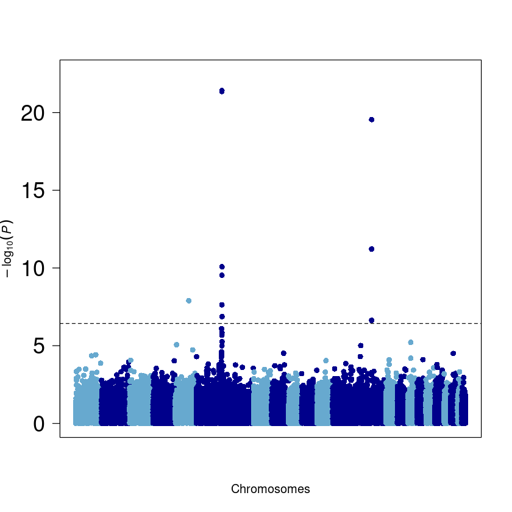

```
qqp(res$p)

chi <- qchisq(res$p, 1, lower.tail = FALSE)
lambda <- median(chi) / qchisq(0.5, 1)
cat("\nInflation factor (lambda):", lambda, "\n")
```

```
Inflation factor (lambda): 0.9892948
```

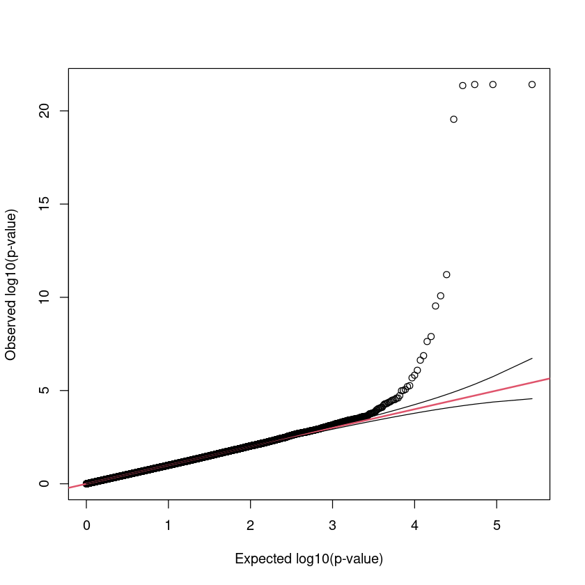

### Estimate SNP Heritability with GCTA

To use GCTA to estimate the heritability accounted for by all autosomal genome-wide SNPs, you need to first estimate the GRM, and then use the GRM to estimate the (SNP) heritability. This can be achieved using the following commands:

```
source ~/heritability_ldscore_human/env.sh
cd $WORK

gcta64 --bfile quantfamdata --autosome --make-grm-bin --out GCTAgrm
```

```
* Genome-wide Complex Trait Analysis (GCTA)
* version v1.94.4 Linux
* Built at Apr  7 2025 11:00:19, by GCC 8.3
* (C) 2010-present, Yang Lab, Westlake University
* Please report bugs to Jian Yang <jian.yang@westlake.edu.cn>
Analysis started at 08:50:31 CEST on Thu Sep 17 2026.
Hostname: emily

Accepted options:
--bfile quantfamdata
--autosome
--make-grm-bin
--out GCTAgrm

Note: This is a multi-thread program. You could specify the number of threads by the --thread-num option to speed up the computation if there are multiple processors in your machine.

Reading PLINK FAM file from [quantfamdata.fam].
498 individuals to be included from [quantfamdata.fam].
Reading PLINK BIM file from [quantfamdata.bim].
134946 SNPs to be included from [quantfamdata.bim].
134946 SNPs from chromosome 1 to chromosome 22 are included in the analysis.
Reading PLINK BED file from [quantfamdata.bed] in SNP-major format ...
Genotype data for 498 individuals and 134946 SNPs to be included from [quantfamdata.bed].
Calculating allele frequencies ...
Recoding genotypes (individual major mode) ...

Calculating the genetic relationship matrix (GRM) ... (Note: default speed-optimized mode, may use huge RAM)

Summary of the GRM:
Mean of diagonals = 1.00289
Variance of diagonals = 0.000422079
Mean of off-diagonals = -0.00201898
Variance of off-diagonals = 0.0004337
GRM of 498 individuals has been saved in the file [GCTAgrm.grm.bin] (in binary format).
Number of SNPs to calculate the genetic relationship between each pair of individuals has been saved in the file [GCTAgrm.grm.N.bin] (in binary format).
IDs for the GRM file [GCTAgrm.grm.bin] have been saved in the file [GCTAgrm.grm.id].

Analysis finished at 08:50:37 CEST on Thu Sep 17 2026
Overall computational time: 6.25 sec.
```

The GRM holds the realised genetic relatedness between every pair of individuals. Use it to identify the individuals who are **not** related.

```
source ~/heritability_ldscore_human/env.sh
cd $WORK

gcta64 --grm GCTAgrm --grm-singleton 0.05 --out unrelated
```

```
* Genome-wide Complex Trait Analysis (GCTA)
* version v1.94.4 Linux
* Built at Apr  7 2025 11:00:19, by GCC 8.3
* (C) 2010-present, Yang Lab, Westlake University
* Please report bugs to Jian Yang <jian.yang@westlake.edu.cn>
Analysis started at 08:50:37 CEST on Thu Sep 17 2026.
Hostname: emily

Options:

--grm GCTAgrm
--grm-singleton 0.05
--out unrelated

Pruning the GRM with a cutoff of 0.050000...
Total number of parts to be processed: 1
    Processing part 1
Related family pairs have been saved to unrelated.family.txt
After pruning the GRM, there are 313 individuals (185 individuals removed).
    Pruned singleton IDs have been saved to unrelated.singleton.txt

Analysis finished at 08:50:38 CEST on Thu Sep 17 2026
Overall computational time: 0.00 sec.
```

**Questions:**

1. How many individuals are unrelated in this sample at a GRM cut-off of 0.05? And at 0.025?
2. Try both cut-offs by changing the number in the cell above. Which cut-off would you choose, and what do you lose by choosing the stricter one?

Now estimate the SNP heritability with REML.

```
source ~/heritability_ldscore_human/env.sh
cd $WORK

gcta64 --reml --grm-bin GCTAgrm --pheno myphenos.txt --out GCTAherit
```

```
* Genome-wide Complex Trait Analysis (GCTA)
* version v1.94.4 Linux
* Built at Apr  7 2025 11:00:19, by GCC 8.3
* (C) 2010-present, Yang Lab, Westlake University
* Please report bugs to Jian Yang <jian.yang@westlake.edu.cn>
Analysis started at 08:50:38 CEST on Thu Sep 17 2026.
Hostname: emily

Accepted options:
--reml
--grm-bin GCTAgrm
--pheno myphenos.txt
--out GCTAherit

Note: This is a multi-thread program. You could specify the number of threads by the --thread-num option to speed up the computation if there are multiple processors in your machine.

Reading IDs of the GRM from [GCTAgrm.grm.id].
498 IDs are read from [GCTAgrm.grm.id].
Reading the GRM from [GCTAgrm.grm.bin].
GRM for 498 individuals are included from [GCTAgrm.grm.bin].
Reading phenotypes from [myphenos.txt].
Non-missing phenotypes of 498 individuals are included from [myphenos.txt].

498 individuals are in common in these files.

Performing  REML analysis ... (Note: may take hours depending on sample size).
498 observations, 1 fixed effect(s), and 2 variance component(s)(including residual variance).
Calculating prior values of variance components by EM-REML ...
Updated prior values: 31.0442    31.1
logL: -1272.01
Running AI-REML algorithm ...
Iter.	logL	V(G)	V(e)
1	-1272.00	30.59118	31.46480
2	-1272.00	29.65709	32.21465
3	-1271.99	29.74687	32.13415
4	-1271.99	29.73822	32.14214
5	-1271.99	29.73907	32.14136
Log-likelihood ratio converged.

Calculating the logLikelihood for the reduced model ...
```

[output cut: 9 more lines]

```
Summary result of REML analysis:
Source	Variance	SE
V(G)	29.739066	9.571996
V(e)	32.141364	8.886474
Vp	61.880430	3.993645
V(G)/Vp	0.480589	0.145944

Sampling variance/covariance of the estimates of variance components:
9.162310e+01	-7.732166e+01
-7.732166e+01	7.896942e+01

Summary result of REML analysis has been saved in the file [GCTAherit.hsq].

Analysis finished at 08:50:38 CEST on Thu Sep 17 2026
Overall computational time: 0.08 sec.
```

**The screen output estimates the SNP heritability V(G)/Vp. What is it?**

- V(G) is the variance explained by the genotyped SNPs, Vp the total phenotypic variance.
- The estimate comes with a standard error. Is the estimate far enough from 0 to be convincing?
- This is **SNP heritability**, not the heritability a twin study would report. Why would you expect the twin estimate to be larger?

# Part 2: LD score regression

The rest of the notebook is based on https://cloufield.github.io/GWASTutorial/08_LDSC/.

LD score regression estimates, from summary statistics alone:

- **inflation** — and, crucially, how much of it is confounding rather than polygenicity
- **heritability** on the observed scale
- **genetic correlation** between two traits

The idea: under true polygenic inheritance, a SNP that tags many other SNPs (a high **LD score**) should have a larger test statistic, because it picks up the effects of everything it is correlated with. Confounding such as population structure, by contrast, lifts *every* SNP equally regardless of its LD score. So regressing the test statistic on the LD score separates the two: the **slope** is polygenic signal and gives the heritability, and the **intercept** is confounding.

### Exploring the summary statistics

The `.txt.gz` files hold GWAS summary statistics for HDL and LDL cholesterol from Biobank Japan. LDL is a risk biomarker for cardiovascular disease.

```
source ~/heritability_ldscore_human/env.sh
cd $WORK

cp -f $DATA/BBJ*.gz .
cp -f $DATA/w_hm3.snplist .
ln -sf $DATA/eas_ldscores .

echo "number of lines for HDLC:"
zcat BBJ_HDLC.txt.gz | wc -l

echo "number of lines for LDLC:"
zcat BBJ_LDLC.txt.gz | wc -l
```

```
number of lines for HDLC:
5961601
number of lines for LDLC:
5961601
```

Let's look at the first 10 lines of the summary statistics for HDL.

```
source ~/heritability_ldscore_human/env.sh
cd $WORK
zcat BBJ_HDLC.txt.gz | head -n 10 | column -t
```

```
SNP          CHR  POS     REF  ALT  Frq     Rsq    BETA       SE        P       LOG10P  N
rs143225517  1    751756  T    C    0.1517  0.951  0.005397   0.007436  0.468   0.3298  70657
rs3094315    1    752566  G    A    0.8438  0.986  -0.005241  0.007217  0.4677  0.33    70657
rs61770173   1    753405  C    A    0.8385  0.832  -0.005624  0.007752  0.4681  0.3297  70657
rs117086422  1    845635  C    T    0.1402  0.869  0.004849   0.008072  0.548   0.2612  70657
rs28612348   1    846078  C    T    0.1419  0.858  0.004844   0.00808   0.5488  0.2606  70657
rs4475691    1    846808  C    T    0.1411  0.998  0.004449   0.007507  0.5534  0.257   70657
rs950122     1    846864  G    C    0.1411  0.998  0.004449   0.007508  0.5534  0.257   70657
rs3905286    1    847228  C    T    0.1391  0.986  0.004522   0.007595  0.5516  0.2584  70657
rs28407778   1    847491  G    A    0.1394  0.985  0.004552   0.007598  0.5491  0.2603  70657

gzip: stdout: Broken pipe
```

- Which columns would LD score regression need, and which are extra?

### Visualise the summary statistics

Before running LD score regression, look at the results in R.

```
# load package for fast reading of data
suppressMessages(require(data.table))
suppressMessages(require(R.utils))

data <- fread("./BBJ_HDLC.txt.gz", sep = "\t", header = TRUE, stringsAsFactors = FALSE, data.table = FALSE)
head(data)
```

A data.frame: 6 × 12

|  | SNP <chr> | CHR <int> | POS <int> | REF <chr> | ALT <chr> | Frq <dbl> | Rsq <dbl> | BETA <dbl> | SE <dbl> | P <dbl> | LOG10P <dbl> | N <int> |
| --- | --- | --- | --- | --- | --- | --- | --- | --- | --- | --- | --- | --- |
| 1 | rs143225517 | 1 | 751756 | T | C | 0.1517 | 0.951 | 0.005397 | 0.007436 | 0.4680 | 0.3298 | 70657 |
| 2 | rs3094315 | 1 | 752566 | G | A | 0.8438 | 0.986 | -0.005241 | 0.007217 | 0.4677 | 0.3300 | 70657 |
| 3 | rs61770173 | 1 | 753405 | C | A | 0.8385 | 0.832 | -0.005624 | 0.007752 | 0.4681 | 0.3297 | 70657 |
| 4 | rs117086422 | 1 | 845635 | C | T | 0.1402 | 0.869 | 0.004849 | 0.008072 | 0.5480 | 0.2612 | 70657 |
| 5 | rs28612348 | 1 | 846078 | C | T | 0.1419 | 0.858 | 0.004844 | 0.008080 | 0.5488 | 0.2606 | 70657 |
| 6 | rs4475691 | 1 | 846808 | C | T | 0.1411 | 0.998 | 0.004449 | 0.007507 | 0.5534 | 0.2570 | 70657 |

Let's make a Manhattan plot.

```
options(repr.plot.width = 10, repr.plot.height = 6)
manPlot(data$P, chr = as.integer(data$CHR), cap = 1e-30, main = "HDLC")
```

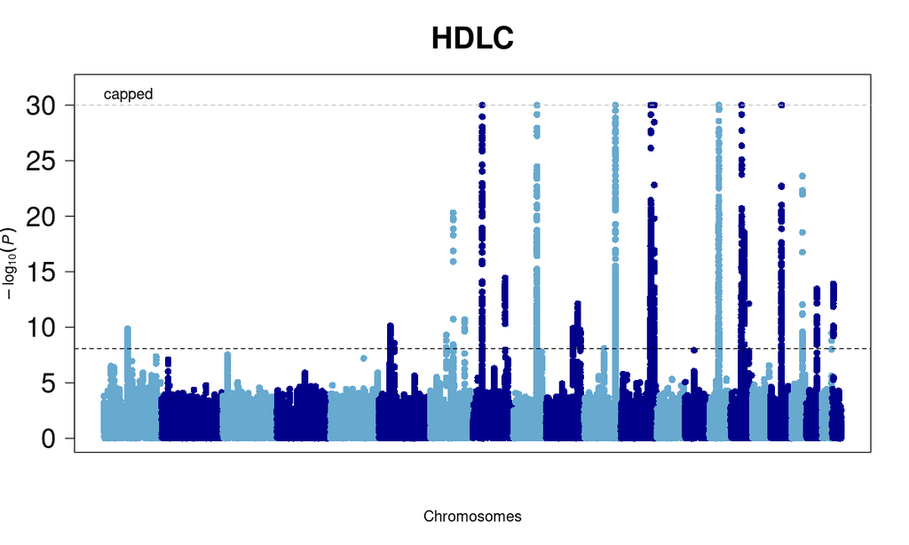

- How many signals are there? Compare this with the Manhattan plot from Part 1 — what does the difference in sample size do to the picture?

Let's zoom in on the strongest signal.

```
w <- which.min(data$P)
pos <- data$POS[w]
chr <- data$CHR[w]

win <- 5e4 # <- change this to zoom in or out
region <- subset(data, CHR == chr & POS > pos-win & POS < pos+win)

plot(region$POS, -log10(region$P), xlab = paste("position on chr", chr),
     ylab = "-log10(p)", main = "strongest HDLC signal", pch = 16, col = "darkblue")
```

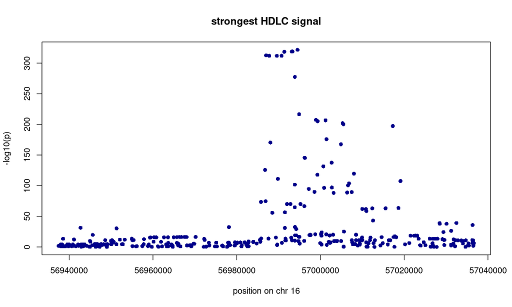

- Based on the plot, what is the candidate gene? (Look up the position.)
- Can we be sure it is the causal gene?
- The lowest p-value is extremely small. What does that say about the effect size, and about the sample size?

```
manPlot(data$P, chr = as.integer(data$CHR), cap = 1e-30, main = "HDLC")
```

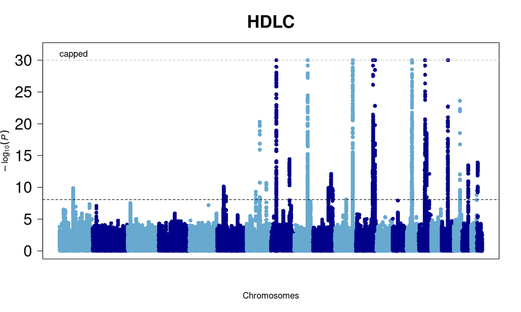

- How many chromosomes have at least one genome-wide significant SNP?

```
qqPlot(data$P, cap = 1e-300, main = "HDLC")

# calculate the inflation factor
X2 <- qchisq(data$P, lower = FALSE, df = 1)
lambda <- median(X2) / qchisq(0.5, 1)
cat("lambda GC =", lambda, "\n")
```

```
lambda GC = 1.141686
```

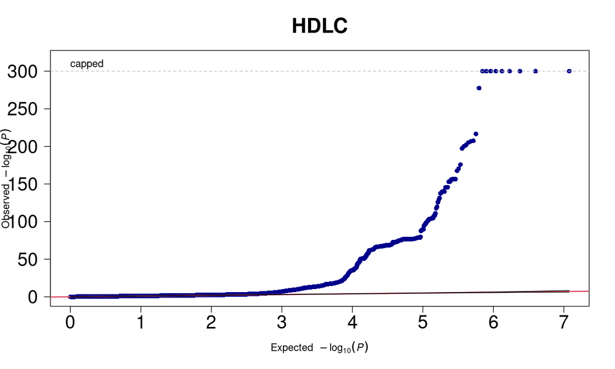

```
dataLDL <- fread("./BBJ_LDLC.txt.gz", sep = "\t", header = TRUE, stringsAsFactors = FALSE, data.table = FALSE)
qqPlot(dataLDL$P, cap = 1e-300, main = "LDLC")

X2 <- qchisq(dataLDL$P, lower = FALSE, df = 1)
cat("lambda GC =", median(X2) / qchisq(0.5, 1), "\n")
```

```
lambda GC = 1.075238
```

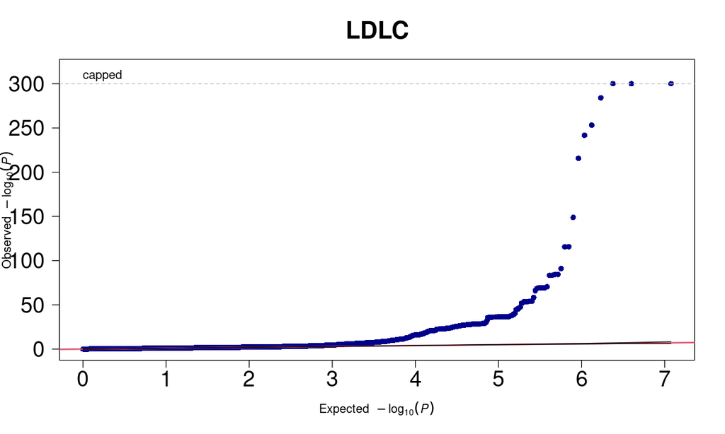

- Are the LDL p-values inflated too?
- Which of the two traits looks more inflated, and would you conclude anything from that on its own?

### Step 1: munge the summary statistics

Before the regression, the raw summary statistics have to be reformatted and restricted to a well-behaved set of SNPs — the HapMap3 list in `w_hm3.snplist`, which is what the LD scores were computed on.

> **⚠️ The conda environment for LDSC is not installed on this server**, so the two `munge_sumstats.py` cells below will fail. Their output (`BBJ_HDLC.sumstats.gz` and `BBJ_LDLC.sumstats.gz`) is supplied with the data, so everything after them still runs. Read the commands, then move on.

```
source ~/heritability_ldscore_human/env.sh
cd $WORK

# takes around 1 min
${LDSC_MUNGE} \
    --sumstats ./BBJ_HDLC.txt.gz \
    --merge-alleles ./w_hm3.snplist \
    --a1 ALT \
    --a2 REF \
    --chunksize 500000 \
    --out BBJ_HDLC
```

```
Command 'conda' not found, did you mean:
  command 'conga' from snap conga (1.5.0)
See 'snap info <snapname>' for additional versions.
```

```
source ~/heritability_ldscore_human/env.sh
cd $WORK

${LDSC_MUNGE} \
    --sumstats ./BBJ_LDLC.txt.gz \
    --merge-alleles ./w_hm3.snplist \
    --a1 ALT \
    --a2 REF \
    --chunksize 500000 \
    --out BBJ_LDLC
```

```
Command 'conda' not found, did you mean:
  command 'conga' from snap conga (1.5.0)
See 'snap info <snapname>' for additional versions.
```

After munging you have two formatted files that can be matched against the LD reference data:

```
source ~/heritability_ldscore_human/env.sh
cd $WORK

# the munged files are supplied with the data, so copy them in
cp -f $DATA/BBJ_HDLC.sumstats.gz $DATA/BBJ_LDLC.sumstats.gz .

zcat BBJ_HDLC.sumstats.gz | head -n 2
zcat BBJ_LDLC.sumstats.gz | head -n 2

echo "---- number of lines ----"
zcat BBJ_HDLC.sumstats.gz | wc -l
zcat BBJ_LDLC.sumstats.gz | wc -l
```

```
SNP	A2	A1	Z	N
rs3094315	G	A	-0.726	70657.000

gzip: stdout: Broken pipe
SNP	A2	A1	Z	N
rs3094315	G	A	-1.442	72866.000

gzip: stdout: Broken pipe
---- number of lines ----
1217312
1217312
```

- The munged file has far fewer columns than the raw one. Which ones survived, and why are those the only ones LD score regression needs?

### LD score regression

Univariate LD score regression estimates heritability **and** the confounding factors — population stratification, cryptic relatedness — at the same time.

The LD scores are the East Asian ones, matching the ancestry of Biobank Japan.

```
source ~/heritability_ldscore_human/env.sh
cd $WORK

${LDSC} \
  --h2 BBJ_HDLC.sumstats.gz \
  --ref-ld-chr eas_ldscores/ \
  --w-ld-chr eas_ldscores/ \
  --out BBJ_HDLC
```

```
Command 'conda' not found, did you mean:
  command 'conga' from snap conga (1.5.0)
See 'snap info <snapname>' for additional versions.
```

- Why does the LD reference panel have to match the ancestry of the GWAS? What would go wrong with a European panel here?

```
source ~/heritability_ldscore_human/env.sh
cd $WORK

${LDSC} \
  --h2 BBJ_LDLC.sumstats.gz \
  --ref-ld-chr eas_ldscores/ \
  --w-ld-chr eas_ldscores/ \
  --out BBJ_LDLC
```

```
Command 'conda' not found, did you mean:
  command 'conga' from snap conga (1.5.0)
See 'snap info <snapname>' for additional versions.
```

```
source ~/heritability_ldscore_human/env.sh
cd $WORK
cat BBJ_HDLC.log
```

[output not shown]

**Questions:**

### Run the cell below to take the quiz

```
from jupyterquiz import display_quiz

display_quiz("https://raw.githubusercontent.com/popgenDK/courses/main/current_exercises/gwas/quiz/heritability_ldscore.json")
```